# SDS 4030 - Statistics for Data Science II: Final Project

`r alpha = 0.05 confint(full_model)`

`## 2.5 % 97.5 % ## (Intercept) -1139787.136 1563672.818 ## Age -9282.145 15180.975 ## Educ -49482.462 90379.388 ## Hours -20949.732 2302.771 ## TVHours -148773.710 18047.486 ## MEduc -67900.262 60469.842 ## FEduc -46177.946 66588.907 ## Sibs -7087.921 124385.860`

`r CInormal = cbind(betabar - qnorm(1 - alpha/2) * SE, betabar + qnorm(1 - alpha/2) * SE) print(CInormal)`

`## [,1] [,2] ## [1,] -1364033.45 1798371.7354 ## [2,] -10816.24 16551.2970 ## [3,] -46362.84 87170.4796 ## [4,] -19406.59 734.9154 ## [5,] -135998.61 4129.9256 ## [6,] -35352.96 27717.6132 ## [7,] -56649.55 76952.5088 ## [8,] -14664.24 133740.8946`

### Percentile Confidence Interval

`r CIpercentile = cbind(apply(betaboot, 2, quantile, probs = alpha/2), apply(betaboot, 2, quantile, probs = 1 - alpha/2)) print(CIpercentile)`

`## [,1] [,2] ## [1,] -1471828.75 1715204.6428 ## [2,] -10940.02 16948.9285 ## [3,] -40216.35 92529.3238 ## [4,] -20480.62 -416.9613 ## [5,] -143808.24 -4352.3522 ## [6,] -36998.65 26156.2166 ## [7,] -49608.70 84743.9113 ## [8,] -6587.59 141444.0849`

### Pivotal Confidence Interval

`r CIpivotal = cbind(2 * beta - apply(betaboot, 2, quantile, probs = 1 - alpha/2), 2 * beta - apply(betaboot, 2, quantile, probs = alpha/2)) print(CIpivotal)`

`## [,1] [,2] ## (Intercept) -1291318.96 1895714.431 ## Age -11050.10 16838.853 ## Educ -51632.40 81113.273 ## Hours -18230.00 1833.655 ## TVHours -126373.87 13082.017 ## MEduc -33586.64 29568.233 ## FEduc -64332.95 70019.661 ## Sibs -24146.15 123885.529`

Step 6:

1. Perform a nonparametric test of overall statistical significance.
2. Perform a non-parametric test of statistical significance for the effect of a single covariate of your choice on the response variable.
3. How do the estimated p-values compare against the p-values obtained under the theoretical null distribution?

## i) Perform a nonparametric test of overall statistical significance.

### Permutation F-test: Getting Permutation F-Statistic and corresponding P-Value

`r alpha = 0.05 f = summary(full_model)$fstatistic[1] print(f)`

`## value ## 1.176606`

`r pvalue = pf(f, p, n - p - 1, lower.tail = FALSE) print(pvalue)`

`## value ## 0.3102288`

`r nperm = 10000 fperm = numeric(nperm) for (k in 1:nperm) { Yperm = sample(Y) perm = lm(Yperm ~ Age + Educ + Hours + TVHours + MEduc + FEduc + Sibs, data = gss) fperm[k] = summary(perm)$fstatistic[1] } pvalue = (1 + sum(fperm > f))/(1 + nperm) print(pvalue)`

`## [1] 0.2986701`

The estimated p-value obtained through the permutation F test 0.2986701 is roughly equal to the one obtained under the theoretical null distribution 0.3102288.

Provides the distribution with theoretical, observed, and empirical information using the entire full model.

`r hist(fperm, "FD", freq = FALSE, main = NA, xlab = "Permutation F Test Statistics") curve(df(x, p, n - p - 1), add = TRUE, lty = 2, lwd = 4) abline(v = qf(1 - alpha, p, n - p - 1), col = 2, lty = 2, lwd = 4) abline(v = quantile(fperm, 1 - alpha), col = 4, lty = 2, lwd = 4) abline(v = f, col = 7, lty = 2, lwd = 4) legend("topright", c("Theoretical Distribution", "Theoretical Quantile", "Empirical Quantile", "Observed Statistic"), col = c(1, 2, 4, 7), lty = rep(2, 4), lwd = rep(4, 4))`

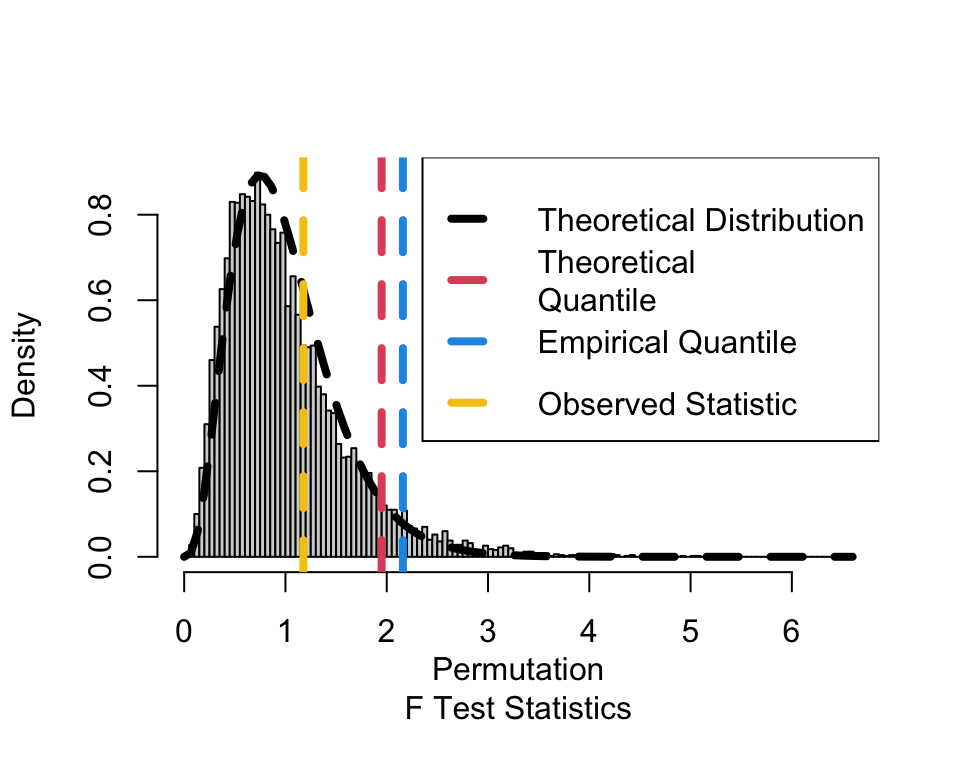

The distribution of the permutation F test statistics almost perfectly agrees with the theoretical null distribution in this case.

## ii) Perform a non-parametric test of statistical significance for the effect of a single covariate of your choice on the response variable.

### Performing a nonparametric permutation t-test for the effect of Hours on Income

`r t = summary(full_model)$coefficients["Hours", 3] print(t)`

`## [1] -1.574122`

`r pvalue = 2 * pt(abs(t), n - p - 1, lower.tail = FALSE) print(pvalue)`

`## [1] 0.1158518`

`r aux = lm(Income ~ Age + Educ + TVHours + MEduc + FEduc + Sibs, data = gss) fitted = aux$fitted.values residuals = aux$residuals tperm = numeric(nperm) for (k in 1:nperm) { Yperm = fitted + sample(residuals) perm = lm(Yperm ~ Age + Educ + Hours + TVHours + MEduc + FEduc + Sibs, data = gss) tperm[k] = summary(perm)$coefficients["Hours", 3] } pvalue = (1 + sum(abs(tperm) > abs(t)))/(1 + nperm) print(pvalue)`

`## [1] 0.1187881`

The estimated p-value obtained through the permutation t-test 0.1187881 after utilizing the Hours covariate is roughly equal to the one obtained under the theoretical null distribution 0.1158518.

Permutation T-Test statistic: Provides the distribution with theoretical, observed, and empirical information using the Hours covariate.

`r hist(tperm, "FD", freq = FALSE, main = NA, xlab = "Permutation t Test Statistics") curve(dt(x, n - p - 1), add = TRUE, lty = 2, lwd = 2) abline(v = qt(c(alpha/2, 1 - alpha/2), n - p - 1), col = 2, lty = 2, lwd = 2) abline(v = quantile(tperm, c(alpha/2, 1 - alpha/2)), col = 4, lty = 2, lwd = 2) abline(v = t, col = 7, lty = 2, lwd = 2) legend("topright", c("Theoretical Distribution", "Theoretical Quantiles", "Empirical Quantiles", "Observed Statistic"), col = c(1, 2, 4, 7), lty = rep(2, 4), lwd = rep(2, 4), cex = 0.5)`

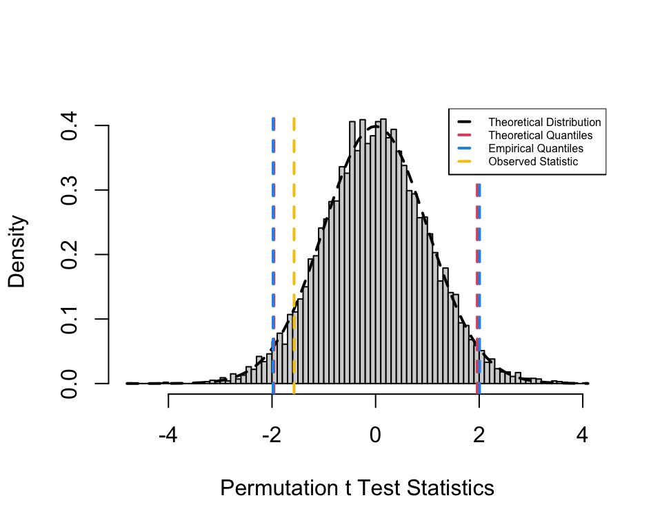

The distribution of the permutation t test statistics almost perfectly agrees with the theoretical null distribution in this case.

### Performing a nonparametric permutation t-test for the effect of TVHours on Income

`r t = summary(full_model)$coefficients["TVHours", 3] print(t)`

`## [1] -1.538195`

`r pvalue = 2 * pt(abs(t), n - p - 1, lower.tail = FALSE) print(pvalue)`

`## [1] 0.1243934`

`r aux = lm(Income ~ Age + Educ + Hours + MEduc + FEduc + Sibs, data = gss) fitted = aux$fitted.values residuals = aux$residuals tperm = numeric(nperm) for (k in 1:nperm) { Yperm = fitted + sample(residuals) perm = lm(Yperm ~ Age + Educ + Hours + TVHours + MEduc + FEduc + Sibs, data = gss) tperm[k] = summary(perm)$coefficients["TVHours", 3] } pvalue = (1 + sum(abs(tperm) > abs(t)))/(1 + nperm) print(pvalue)`

`## [1] 0.1022898`

The estimated p-value obtained through the permutation permutation t-test after utilizing the TVHours covariate 0.1022898 is slightly smaller than the one to the one obtained under the theoretical null distribution 0.1243934.

Permutation T-Test statistic: Provides the distribution with theoretical, observed, and empirical information using the TVHours covariate.

`r hist(tperm, "FD", freq = FALSE, main = NA, xlab = "Permutation t Test Statistics") curve(dt(x, n - p - 1), add = TRUE, lty = 2, lwd = 2) abline(v = qt(c(alpha/2, 1 - alpha/2), n - p - 1), col = 2, lty = 2, lwd = 2) abline(v = quantile(tperm, c(alpha/2, 1 - alpha/2)), col = 4, lty = 2, lwd = 2) abline(v = t, col = 7, lty = 2, lwd = 2) legend("topright", c("Theoretical Distribution", "Theoretical Quantiles", "Empirical Quantiles", "Observed Statistic"), col = c(1, 2, 4, 7), lty = rep(2, 4), lwd = rep(2, 4), cex = 0.5)`

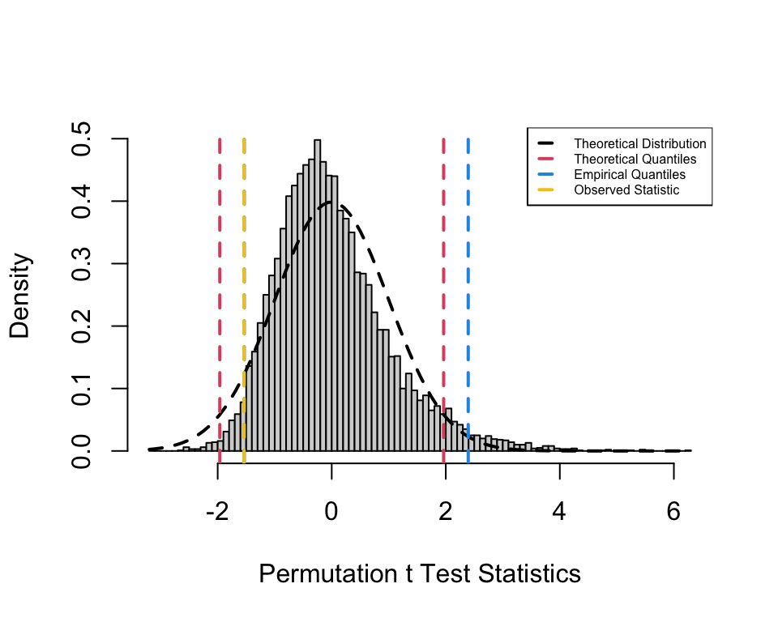

The distribution of the permutation t test statistics is slightly more concentrated than the theoretical null distribution in this case.

## iii) How do the estimated p-values compare against the p-values obtained under the theoretical null distribution?

### Hours covariate

The Permutation T Test statistic almost perfectly agrees with the theoretical null distrubtion and that the p-value compares very similarly to how the theoretical null distribution expects it to act. The p-value is not significant since the permutation t test almost perfectly follows the theoretical null distribution. So the results from the parametric classic t test are consistent with the conclusions from the permutation t test, in both cases we fail to reject the null that the coefficient for Hours equals zero.

A very similar story is told with the permutation F test. The histogram and the theoretical distribution are essentially equal, with little variation difference between them, and the overall significances and p-values of the permutation F test and the theoretical null distribution are quite reasonable and similar, both indicating that the model is not statistically significant. This agreement tells us that the assumptions of the F-test do not heavily affect our inference.

Step 7:

1. Are there any covariates which should be transformed?
2. Should a transformation be applied to the response variable?
3. Refit your linear model to account for all your transformed variables.
4. Are the standardized residuals from your linear model normally distributed?
5. Construct 95 percent simultaneous confidence bands to test the global null hypothesis of normality for the standardized residuals.

## i) Are there any covariates which should be transformed?

We will look at each coefficient individually using a histogram and boxplot to look for skew.

### Age

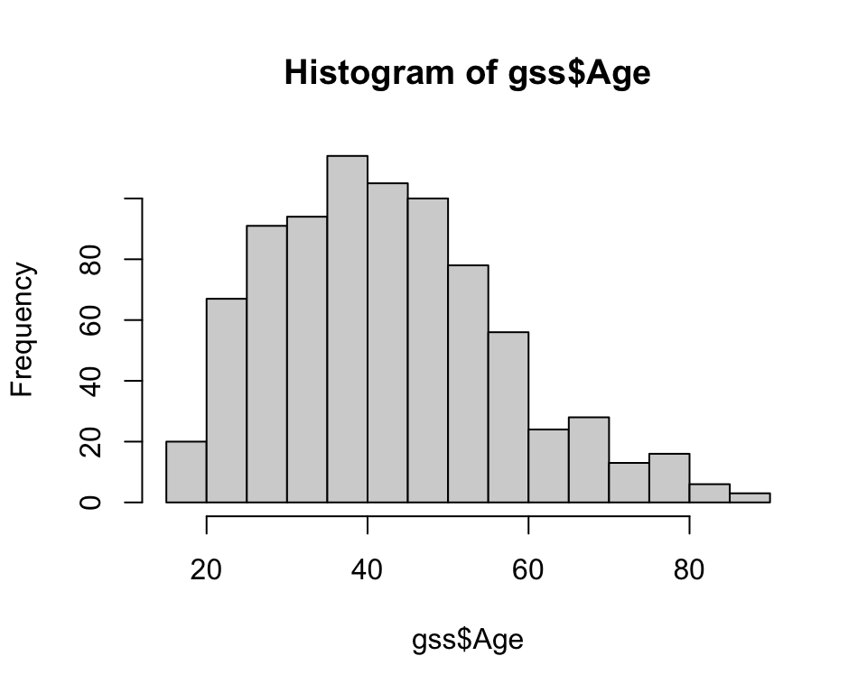

```r
hist(gss$Age)
```

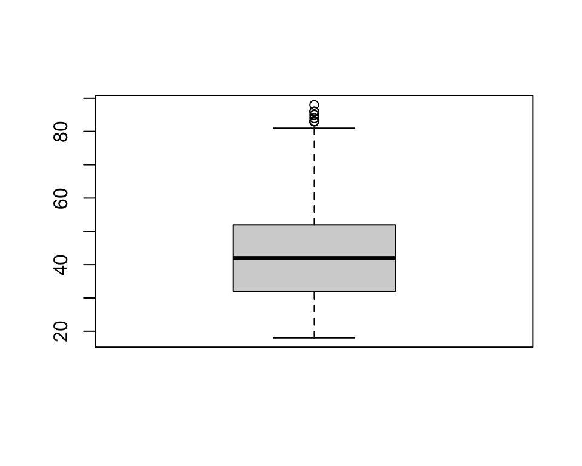

```r
boxplot(gss$Age)
```

We can see that the histogram is roughly bell shaped with mild right skew and likewise the boxplot has a reasonable spread with some large outliers but not extreme enough to require a transformation.

### Education

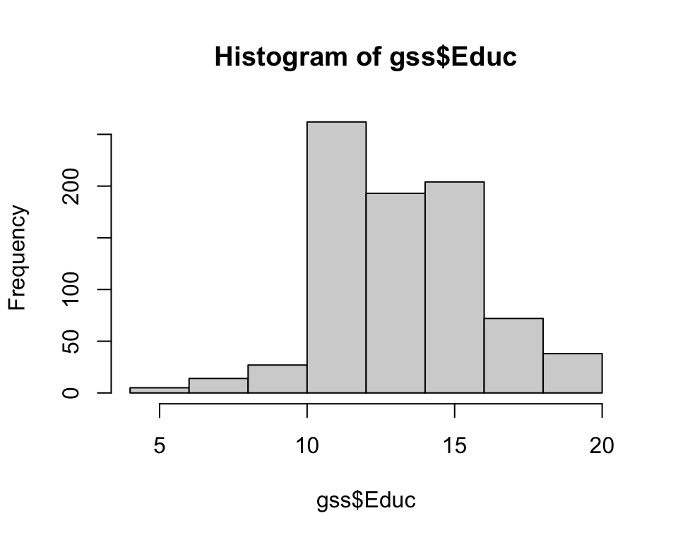

```r
hist(gss$Educ)
```

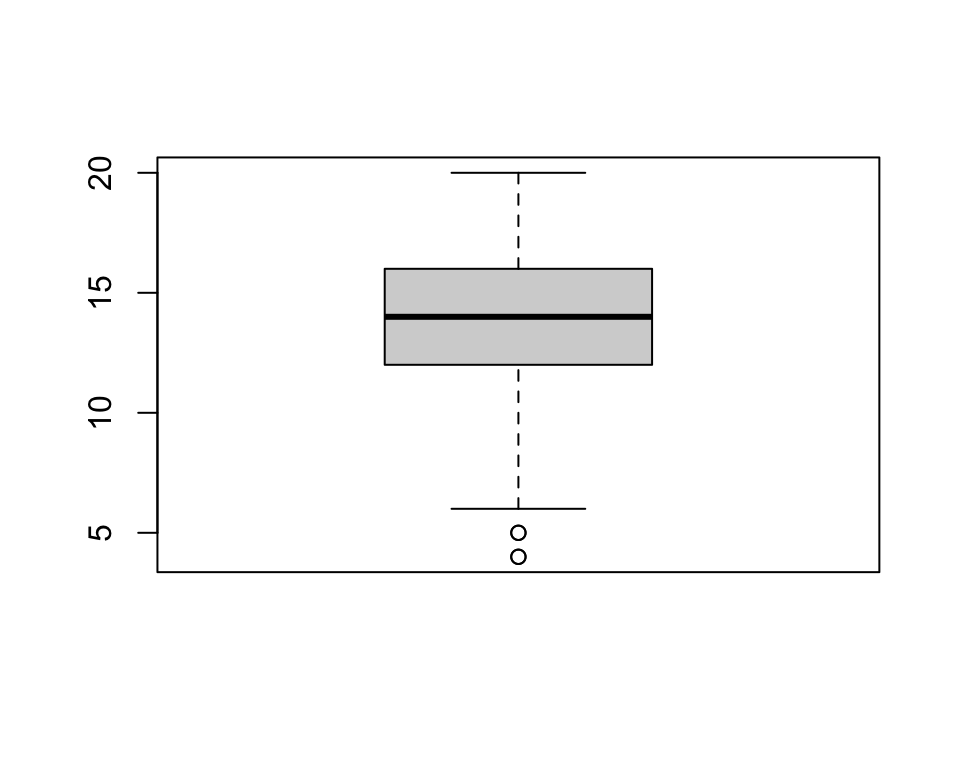

```r
boxplot(gss$Educ)
```

The histogram for education is roughly normal with a slight left tail and the boxplot also has a reasonable spread with some low outliers, but again not extreme enough to suggest a transformation.

### Hours

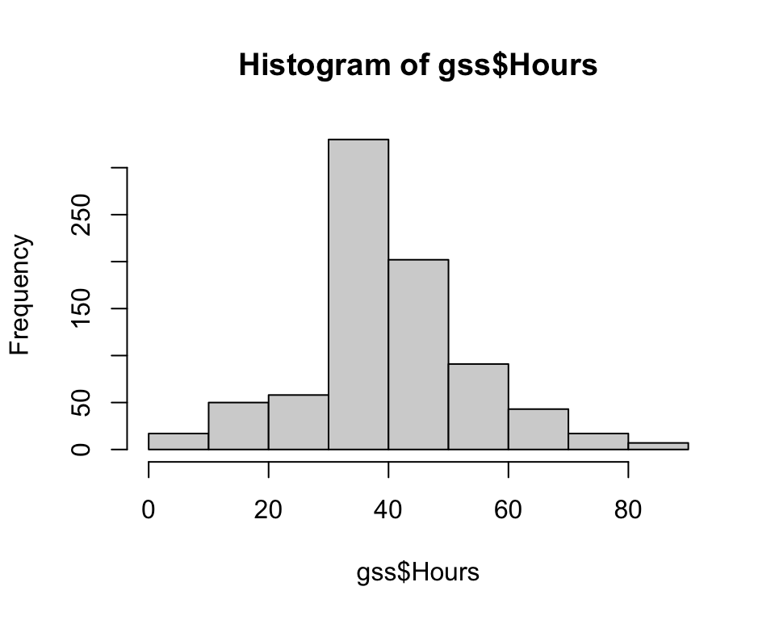

```r
hist(gss$Hours)
```

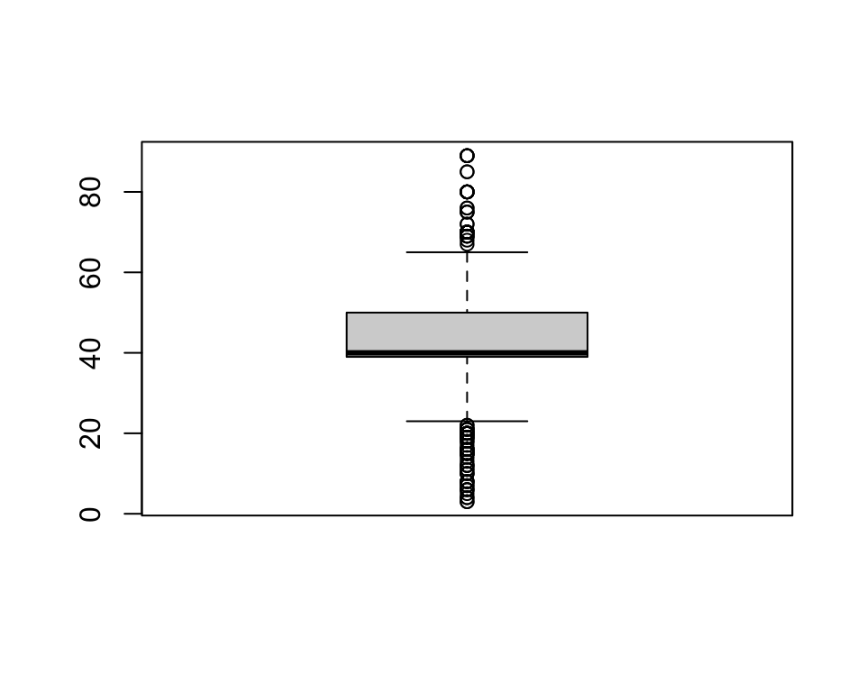

```r
boxplot(gss$Hours)
```

The histogram for hours is roughly symmetrical with some right skew. The boxplot for hours contains many outliers, but the outliers are on both the lower and upper ends so there is not evidence that a transformation would not improve anything.

### TVHours

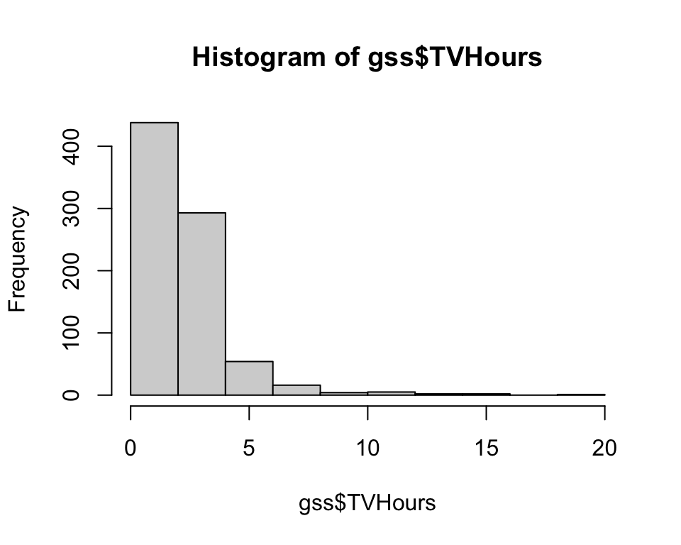

```r
hist(gss$TVHours)
```

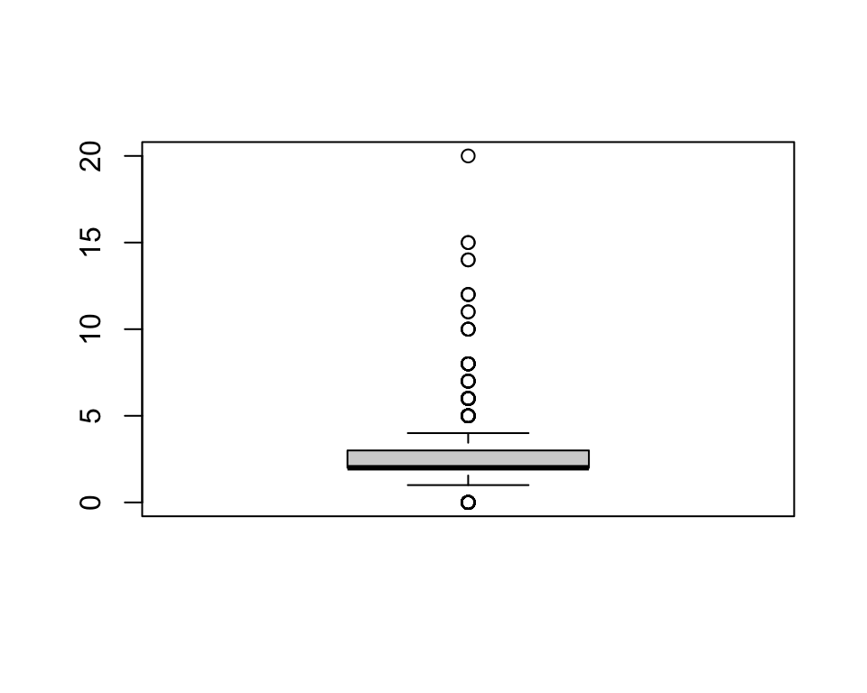

```r
boxplot(gss$TVHours)
```

The histogram for TVHours is extremely right skewed with most values below 5 hours and a few very large values, and likewise the boxplot for TVHours also has severe skew and many high outliers, so a transformation is necessary. But since it includes 0 values, specifically a log transformation like log(TVHours + 1) could help reduce skew and improve variance for the TVHours covariate.

### MEduc

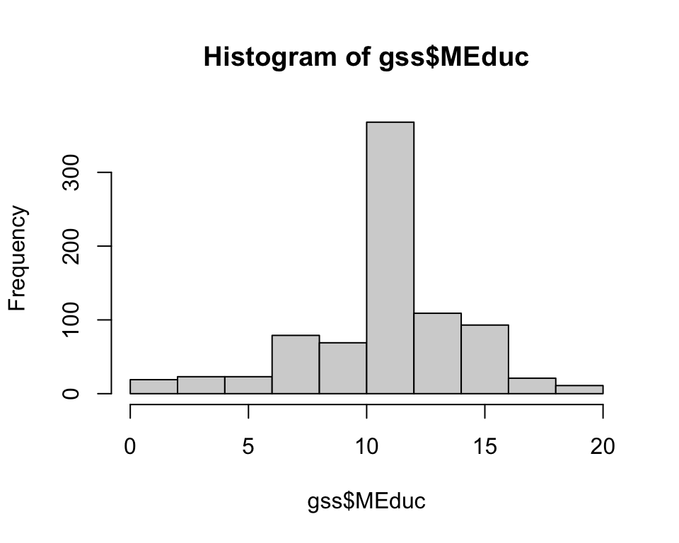

```r
hist(gss$MEduc)
```

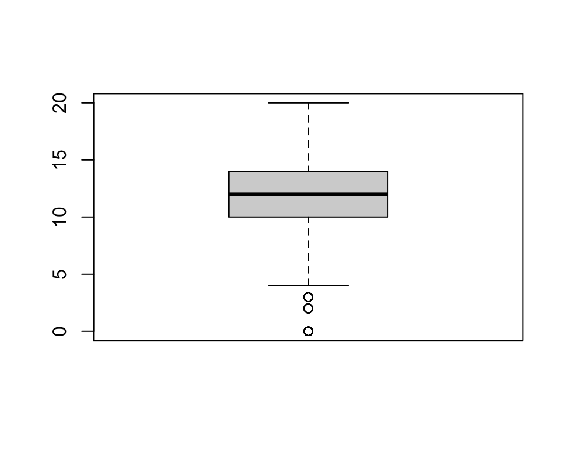

```r
boxplot(gss$MEduc)
```

The histogram MEduc for mother’s education is roughly symmetric with a very slight left tail. The boxplot for MEduc is also reasonably spread with a few low outliers, so a transformation is not necessary.

### FEduc

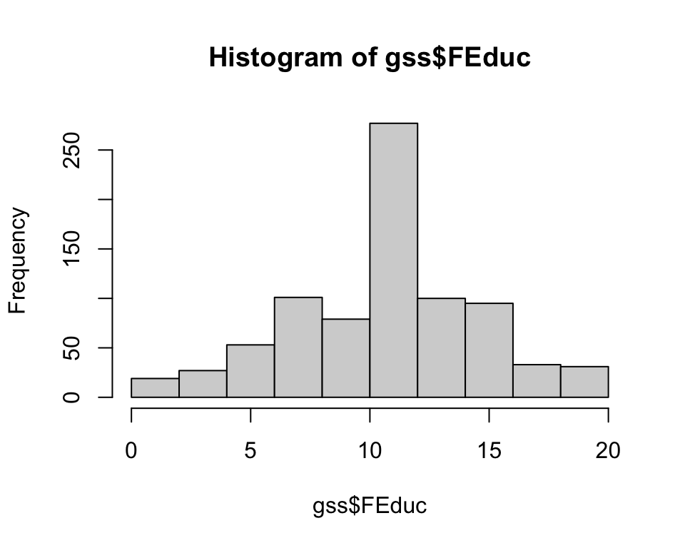

```r
hist(gss$FEduc)
```

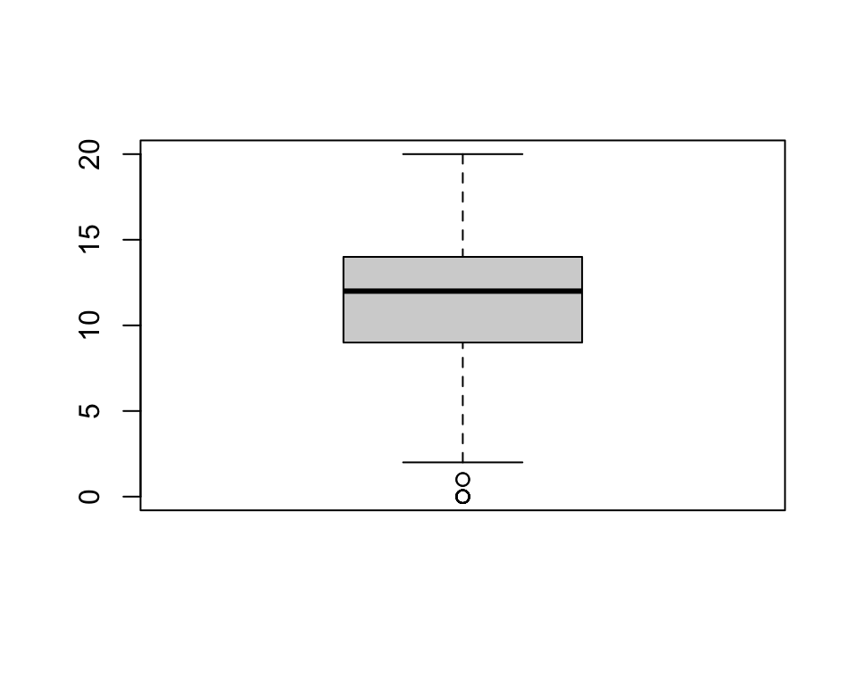

```r
boxplot(gss$FEduc)
```

The histogram FEduc for father’s education is also roughly symmetric with a very slight left tail, and the boxplot is reasonable with a couple low outliers. So a transformation is not needed for the FEduc covariate.